# Risk Factor Analysis

## Outcome Variable

**Outcome Variable:** stunted

## Predictor Variables

**Intervention Variable:** gagebrth

**Adjustment Set:**

unadjusted

## Stratifying Variables

The analysis was stratified on these variable(s):

- agecat
- studyid

The following strata were considered:

- agecat: 12 months, studyid: ki1000108-CMC-V-BCS-2002
- agecat: 12 months, studyid: ki1000108-IRC
- agecat: 12 months, studyid: ki1000109-EE
- agecat: 12 months, studyid: ki1066203-TanzaniaChild2
- agecat: 12 months, studyid: ki1101329-Keneba
- agecat: 12 months, studyid: ki1113344-GMS-Nepal
- agecat: 12 months, studyid: ki1135781-COHORTS
- agecat: 18 months, studyid: ki1000108-CMC-V-BCS-2002
- agecat: 18 months, studyid: ki1000108-IRC
- agecat: 18 months, studyid: ki1000109-EE
- agecat: 18 months, studyid: ki1066203-TanzaniaChild2
- agecat: 18 months, studyid: ki1101329-Keneba
- agecat: 18 months, studyid: ki1113344-GMS-Nepal
- agecat: 18 months, studyid: ki1135781-COHORTS
- agecat: 24 months, studyid: ki1000108-CMC-V-BCS-2002
- agecat: 24 months, studyid: ki1000108-IRC
- agecat: 24 months, studyid: ki1066203-TanzaniaChild2
- agecat: 24 months, studyid: ki1101329-Keneba
- agecat: 24 months, studyid: ki1113344-GMS-Nepal
- agecat: 24 months, studyid: ki1135781-COHORTS
- agecat: 3 months, studyid: ki1000108-CMC-V-BCS-2002
- agecat: 3 months, studyid: ki1000108-IRC
- agecat: 3 months, studyid: ki1000109-EE
- agecat: 3 months, studyid: ki1066203-TanzaniaChild2
- agecat: 3 months, studyid: ki1101329-Keneba
- agecat: 3 months, studyid: ki1113344-GMS-Nepal
- agecat: 3 months, studyid: ki1135781-COHORTS
- agecat: 6 months, studyid: ki1000108-CMC-V-BCS-2002
- agecat: 6 months, studyid: ki1000108-IRC
- agecat: 6 months, studyid: ki1000109-EE
- agecat: 6 months, studyid: ki1066203-TanzaniaChild2
- agecat: 6 months, studyid: ki1101329-Keneba
- agecat: 6 months, studyid: ki1113344-GMS-Nepal
- agecat: 6 months, studyid: ki1135781-COHORTS
- agecat: 9 months, studyid: ki1000108-CMC-V-BCS-2002
- agecat: 9 months, studyid: ki1000108-IRC
- agecat: 9 months, studyid: ki1000109-EE
- agecat: 9 months, studyid: ki1066203-TanzaniaChild2
- agecat: 9 months, studyid: ki1101329-Keneba
- agecat: 9 months, studyid: ki1113344-GMS-Nepal
- agecat: 9 months, studyid: ki1135781-COHORTS
- agecat: Birth, studyid: ki1000108-CMC-V-BCS-2002
- agecat: Birth, studyid: ki1000108-IRC
- agecat: Birth, studyid: ki1000109-EE
- agecat: Birth, studyid: ki1101329-Keneba
- agecat: Birth, studyid: ki1135781-COHORTS

### Dropped Strata

Some strata were dropped due to rare outcomes:

- agecat: 12 months, studyid: ki1000109-EE
- agecat: 12 months, studyid: ki1113344-GMS-Nepal
- agecat: 18 months, studyid: ki1000109-EE
- agecat: 18 months, studyid: ki1113344-GMS-Nepal
- agecat: 24 months, studyid: ki1066203-TanzaniaChild2
- agecat: 24 months, studyid: ki1113344-GMS-Nepal
- agecat: 3 months, studyid: ki1000109-EE
- agecat: 3 months, studyid: ki1113344-GMS-Nepal
- agecat: 6 months, studyid: ki1000109-EE
- agecat: 6 months, studyid: ki1113344-GMS-Nepal
- agecat: 9 months, studyid: ki1000109-EE
- agecat: 9 months, studyid: ki1113344-GMS-Nepal
- agecat: Birth, studyid: ki1000108-CMC-V-BCS-2002
- agecat: Birth, studyid: ki1000109-EE

## Methods Detail

We’re interested in the causal parameters $E[Y_a]$ for all values of $a \in \mathcal{A}$. These parameters represent the mean outcome if, possibly contrary to fact, we intervened to set all units to have $A=a$. Under the randomization and positivity assumptions, these are identified by the statistical parameters $\psi_a=E_W[E_{Y|A,W}(Y|A=a,W)]$. In addition, we’re interested in the mean of $Y$, $E[Y]$ under no intervention (the observed mean). We will estimate these parameters by using SuperLearner to fit the relevant likelihood factors – $E_{Y|A,W}(Y|A=a,W)$ and $p(A=a|W)$, and then updating our likelihood fit using a joint TMLE.

For unadjusted analyses ($W=\{\}$), initial likelihoods were estimated using Lrnr_glm to estimate the simple $E(Y|A)$ and Lrnr_mean to estimate $p(A)$. For adjusted analyses, a small library containing Lrnr_glmnet, Lrnr_xgboost, and Lrnr_mean was used.

Having estimated these parameters, we will then use the delta method to estimate relative risks and attributable risks relative to a prespecified baseline level of $A$.

# Results Detail

## Results Plots

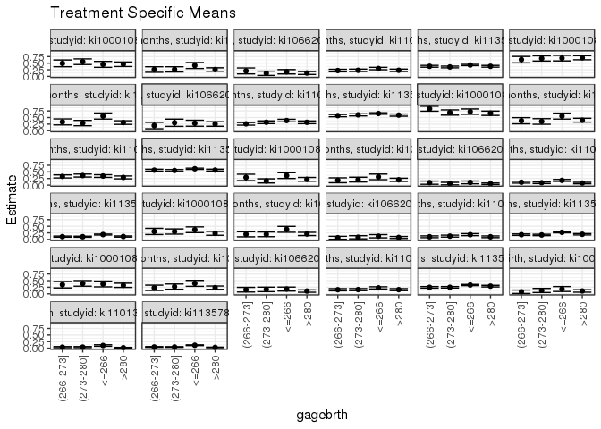

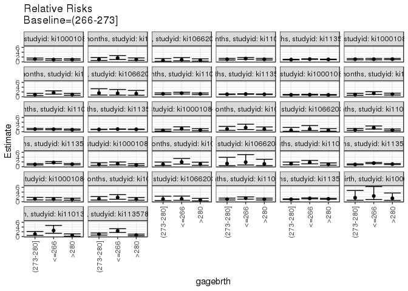

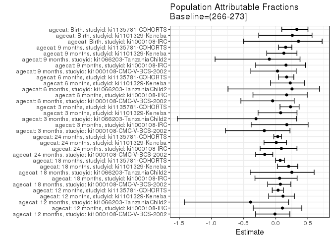

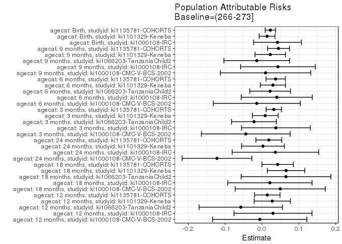

## Data Summary

| agecat | studyid | A | n | nA | nAY0 | nAY1 |
| --- | --- | --- | --- | --- | --- | --- |
| 12 months | ki1000108-CMC-V-BCS-2002 | (266-273] | 346 | 59 | 30 | 29 |
| 12 months | ki1000108-CMC-V-BCS-2002 | (273-280] | 346 | 83 | 37 | 46 |
| 12 months | ki1000108-CMC-V-BCS-2002 | <=266 | 346 | 75 | 41 | 34 |
| 12 months | ki1000108-CMC-V-BCS-2002 | >280 | 346 | 129 | 70 | 59 |
| 12 months | ki1000108-IRC | (266-273] | 386 | 66 | 49 | 17 |
| 12 months | ki1000108-IRC | (273-280] | 386 | 76 | 56 | 20 |
| 12 months | ki1000108-IRC | <=266 | 386 | 73 | 43 | 30 |
| 12 months | ki1000108-IRC | >280 | 386 | 171 | 127 | 44 |
| 12 months | ki1000109-EE | (266-273] | 357 | 48 | 20 | 28 |
| 12 months | ki1000109-EE | (273-280] | 357 | 7 | 2 | 5 |
| 12 months | ki1000109-EE | <=266 | 357 | 285 | 74 | 211 |
| 12 months | ki1000109-EE | >280 | 357 | 17 | 6 | 11 |
| 12 months | ki1066203-TanzaniaChild2 | (266-273] | 334 | 49 | 39 | 10 |
| 12 months | ki1066203-TanzaniaChild2 | (273-280] | 334 | 61 | 54 | 7 |
| 12 months | ki1066203-TanzaniaChild2 | <=266 | 334 | 81 | 67 | 14 |
| 12 months | ki1066203-TanzaniaChild2 | >280 | 334 | 143 | 125 | 18 |
| 12 months | ki1101329-Keneba | (266-273] | 1300 | 274 | 214 | 60 |
| 12 months | ki1101329-Keneba | (273-280] | 1300 | 315 | 243 | 72 |
| 12 months | ki1101329-Keneba | <=266 | 1300 | 396 | 279 | 117 |
| 12 months | ki1101329-Keneba | >280 | 1300 | 315 | 243 | 72 |
| 12 months | ki1113344-GMS-Nepal | (266-273] | 558 | 553 | 363 | 190 |
| 12 months | ki1113344-GMS-Nepal | (273-280] | 558 | 0 | 0 | 0 |
| 12 months | ki1113344-GMS-Nepal | <=266 | 558 | 1 | 1 | 0 |
| 12 months | ki1113344-GMS-Nepal | >280 | 558 | 4 | 3 | 1 |
| 12 months | ki1135781-COHORTS | (266-273] | 4037 | 760 | 471 | 289 |
| 12 months | ki1135781-COHORTS | (273-280] | 4037 | 831 | 536 | 295 |
| 12 months | ki1135781-COHORTS | <=266 | 4037 | 1624 | 927 | 697 |
| 12 months | ki1135781-COHORTS | >280 | 4037 | 822 | 509 | 313 |
| 18 months | ki1000108-CMC-V-BCS-2002 | (266-273] | 347 | 60 | 22 | 38 |
| 18 months | ki1000108-CMC-V-BCS-2002 | (273-280] | 347 | 84 | 27 | 57 |

[output cut: 166 more lines]

## Results Table

### Parameter: TSM

| agecat | studyid | intervention_level | baseline_level | estimate | ci_lower | ci_upper |
| --- | --- | --- | --- | --- | --- | --- |
| 12 months | ki1000108-CMC-V-BCS-2002 | (266-273] | NA | 0.4915254 | 0.3637762 | 0.6192746 |
| 12 months | ki1000108-CMC-V-BCS-2002 | (273-280] | NA | 0.5542169 | 0.4471293 | 0.6613045 |
| 12 months | ki1000108-CMC-V-BCS-2002 | <=266 | NA | 0.4533333 | 0.3405055 | 0.5661611 |
| 12 months | ki1000108-CMC-V-BCS-2002 | >280 | NA | 0.4573643 | 0.3712715 | 0.5434572 |
| 12 months | ki1000108-IRC | (266-273] | NA | 0.2575758 | 0.1519383 | 0.3632132 |
| 12 months | ki1000108-IRC | (273-280] | NA | 0.2631579 | 0.1640291 | 0.3622867 |
| 12 months | ki1000108-IRC | <=266 | NA | 0.4109589 | 0.2979476 | 0.5239702 |
| 12 months | ki1000108-IRC | >280 | NA | 0.2573099 | 0.1917037 | 0.3229162 |
| 12 months | ki1066203-TanzaniaChild2 | (266-273] | NA | 0.2040816 | 0.0910663 | 0.3170970 |
| 12 months | ki1066203-TanzaniaChild2 | (273-280] | NA | 0.1147541 | 0.0346508 | 0.1948574 |
| 12 months | ki1066203-TanzaniaChild2 | <=266 | NA | 0.1728395 | 0.0903739 | 0.2553052 |
| 12 months | ki1066203-TanzaniaChild2 | >280 | NA | 0.1258741 | 0.0714256 | 0.1803227 |
| 12 months | ki1101329-Keneba | (266-273] | NA | 0.2189781 | 0.1699921 | 0.2679641 |
| 12 months | ki1101329-Keneba | (273-280] | NA | 0.2285714 | 0.1821820 | 0.2749608 |
| 12 months | ki1101329-Keneba | <=266 | NA | 0.2954545 | 0.2505006 | 0.3404085 |
| 12 months | ki1101329-Keneba | >280 | NA | 0.2285714 | 0.1821820 | 0.2749608 |
| 12 months | ki1135781-COHORTS | (266-273] | NA | 0.3802632 | 0.3457455 | 0.4147808 |
| 12 months | ki1135781-COHORTS | (273-280] | NA | 0.3549940 | 0.3224558 | 0.3875322 |
| 12 months | ki1135781-COHORTS | <=266 | NA | 0.4291872 | 0.4051115 | 0.4532629 |
| 12 months | ki1135781-COHORTS | >280 | NA | 0.3807786 | 0.3475796 | 0.4139776 |
| 18 months | ki1000108-CMC-V-BCS-2002 | (266-273] | NA | 0.6333333 | 0.5112234 | 0.7554433 |
| 18 months | ki1000108-CMC-V-BCS-2002 | (273-280] | NA | 0.6785714 | 0.5785541 | 0.7785887 |
| 18 months | ki1000108-CMC-V-BCS-2002 | <=266 | NA | 0.6891892 | 0.5835862 | 0.7947922 |
| 18 months | ki1000108-CMC-V-BCS-2002 | >280 | NA | 0.7054264 | 0.6266488 | 0.7842039 |
| 18 months | ki1000108-IRC | (266-273] | NA | 0.3333333 | 0.2194571 | 0.4472096 |
| 18 months | ki1000108-IRC | (273-280] | NA | 0.2894737 | 0.1873799 | 0.3915674 |
| 18 months | ki1000108-IRC | <=266 | NA | 0.5555556 | 0.4406297 | 0.6704814 |
| 18 months | ki1000108-IRC | >280 | NA | 0.3081395 | 0.2390472 | 0.3772319 |
| 18 months | ki1066203-TanzaniaChild2 | (266-273] | NA | 0.1951220 | 0.0735668 | 0.3166771 |
| 18 months | ki1066203-TanzaniaChild2 | (273-280] | NA | 0.3023256 | 0.1647704 | 0.4398807 |

[output cut: 98 more lines]

### Parameter: E(Y)

| agecat | studyid | intervention_level | baseline_level | estimate | ci_lower | ci_upper |
| --- | --- | --- | --- | --- | --- | --- |
| 12 months | ki1000108-CMC-V-BCS-2002 | NA | NA | 0.4855491 | 0.4812520 | 0.4898462 |
| 12 months | ki1000108-IRC | NA | NA | 0.2875648 | 0.2816081 | 0.2935215 |
| 12 months | ki1066203-TanzaniaChild2 | NA | NA | 0.1467066 | 0.1432749 | 0.1501382 |
| 12 months | ki1101329-Keneba | NA | NA | 0.2469231 | 0.2451649 | 0.2486812 |
| 12 months | ki1135781-COHORTS | NA | NA | 0.3948477 | 0.3939316 | 0.3957637 |
| 18 months | ki1000108-CMC-V-BCS-2002 | NA | NA | 0.6829971 | 0.6803599 | 0.6856343 |
| 18 months | ki1000108-IRC | NA | NA | 0.3549223 | 0.3452342 | 0.3646104 |
| 18 months | ki1066203-TanzaniaChild2 | NA | NA | 0.2603306 | 0.2560010 | 0.2646602 |
| 18 months | ki1101329-Keneba | NA | NA | 0.3259032 | 0.3234632 | 0.3283431 |
| 18 months | ki1135781-COHORTS | NA | NA | 0.6151625 | 0.6139529 | 0.6163720 |
| 24 months | ki1000108-CMC-V-BCS-2002 | NA | NA | 0.7114286 | 0.7051249 | 0.7177322 |
| 24 months | ki1000108-IRC | NA | NA | 0.4153846 | 0.4084826 | 0.4222867 |
| 24 months | ki1101329-Keneba | NA | NA | 0.3321799 | 0.3307018 | 0.3336581 |
| 24 months | ki1135781-COHORTS | NA | NA | 0.5846496 | 0.5837973 | 0.5855018 |
| 3 months | ki1000108-CMC-V-BCS-2002 | NA | NA | 0.2470588 | 0.2392971 | 0.2548205 |
| 3 months | ki1000108-IRC | NA | NA | 0.2196382 | 0.2151427 | 0.2241338 |
| 3 months | ki1066203-TanzaniaChild2 | NA | NA | 0.0703704 | 0.0684454 | 0.0722953 |
| 3 months | ki1101329-Keneba | NA | NA | 0.1171983 | 0.1150405 | 0.1193562 |
| 3 months | ki1135781-COHORTS | NA | NA | 0.1395810 | 0.1384605 | 0.1407016 |
| 6 months | ki1000108-CMC-V-BCS-2002 | NA | NA | 0.2910663 | 0.2856512 | 0.2964814 |
| 6 months | ki1000108-IRC | NA | NA | 0.2371134 | 0.2300633 | 0.2441635 |
| 6 months | ki1066203-TanzaniaChild2 | NA | NA | 0.0870488 | 0.0851514 | 0.0889462 |
| 6 months | ki1101329-Keneba | NA | NA | 0.1317322 | 0.1299160 | 0.1335484 |
| 6 months | ki1135781-COHORTS | NA | NA | 0.2181316 | 0.2168372 | 0.2194261 |
| 9 months | ki1000108-CMC-V-BCS-2002 | NA | NA | 0.3546512 | 0.3515592 | 0.3577431 |
| 9 months | ki1000108-IRC | NA | NA | 0.2706186 | 0.2643330 | 0.2769041 |
| 9 months | ki1066203-TanzaniaChild2 | NA | NA | 0.1421569 | 0.1389624 | 0.1453513 |
| 9 months | ki1101329-Keneba | NA | NA | 0.1779230 | 0.1762933 | 0.1795527 |
| 9 months | ki1135781-COHORTS | NA | NA | 0.2904909 | 0.2893243 | 0.2916574 |
| Birth | ki1000108-IRC | NA | NA | 0.1192412 | 0.1158740 | 0.1226084 |
| Birth | ki1101329-Keneba | NA | NA | 0.0541254 | 0.0524515 | 0.0557993 |
| Birth | ki1135781-COHORTS | NA | NA | 0.0696766 | 0.0686577 | 0.0706955 |

### Parameter: RR

| agecat | studyid | intervention_level | baseline_level | estimate | ci_lower | ci_upper |
| --- | --- | --- | --- | --- | --- | --- |
| 12 months | ki1000108-CMC-V-BCS-2002 | (273-280] | (266-273] | 1.1275447 | 0.8156114 | 1.5587779 |
| 12 months | ki1000108-CMC-V-BCS-2002 | <=266 | (266-273] | 0.9222989 | 0.6435613 | 1.3217625 |
| 12 months | ki1000108-CMC-V-BCS-2002 | >280 | (266-273] | 0.9304999 | 0.6750672 | 1.2825833 |
| 12 months | ki1000108-IRC | (273-280] | (266-273] | 1.0216718 | 0.5854225 | 1.7830085 |
| 12 months | ki1000108-IRC | <=266 | (266-273] | 1.5954875 | 0.9737469 | 2.6142114 |
| 12 months | ki1000108-IRC | >280 | (266-273] | 0.9989680 | 0.6163438 | 1.6191241 |
| 12 months | ki1066203-TanzaniaChild2 | (273-280] | (266-273] | 0.5622951 | 0.2306725 | 1.3706698 |
| 12 months | ki1066203-TanzaniaChild2 | <=266 | (266-273] | 0.8469136 | 0.4077407 | 1.7591145 |
| 12 months | ki1066203-TanzaniaChild2 | >280 | (266-273] | 0.6167832 | 0.3054616 | 1.2453989 |
| 12 months | ki1101329-Keneba | (273-280] | (266-273] | 1.0438095 | 0.7716910 | 1.4118842 |
| 12 months | ki1101329-Keneba | <=266 | (266-273] | 1.3492424 | 1.0294258 | 1.7684180 |
| 12 months | ki1101329-Keneba | >280 | (266-273] | 1.0438095 | 0.7716910 | 1.4118842 |
| 12 months | ki1135781-COHORTS | (273-280] | (266-273] | 0.9335482 | 0.8205645 | 1.0620886 |
| 12 months | ki1135781-COHORTS | <=266 | (266-273] | 1.1286584 | 1.0144251 | 1.2557553 |
| 12 months | ki1135781-COHORTS | >280 | (266-273] | 1.0013555 | 0.8829313 | 1.1356634 |
| 18 months | ki1000108-CMC-V-BCS-2002 | (273-280] | (266-273] | 1.0714286 | 0.8405508 | 1.3657226 |
| 18 months | ki1000108-CMC-V-BCS-2002 | <=266 | (266-273] | 1.0881935 | 0.8506465 | 1.3920764 |
| 18 months | ki1000108-CMC-V-BCS-2002 | >280 | (266-273] | 1.1138311 | 0.8913610 | 1.3918263 |
| 18 months | ki1000108-IRC | (273-280] | (266-273] | 0.8684211 | 0.5314763 | 1.4189816 |
| 18 months | ki1000108-IRC | <=266 | (266-273] | 1.6666667 | 1.1178936 | 2.4848320 |
| 18 months | ki1000108-IRC | >280 | (266-273] | 0.9244186 | 0.6143255 | 1.3910375 |
| 18 months | ki1066203-TanzaniaChild2 | (273-280] | (266-273] | 1.5494186 | 0.7163742 | 3.3511788 |
| 18 months | ki1066203-TanzaniaChild2 | <=266 | (266-273] | 1.4520833 | 0.6913580 | 3.0498614 |
| 18 months | ki1066203-TanzaniaChild2 | >280 | (266-273] | 1.3073980 | 0.6432609 | 2.6572256 |
| 18 months | ki1101329-Keneba | (273-280] | (266-273] | 1.2307692 | 0.9556084 | 1.5851607 |
| 18 months | ki1101329-Keneba | <=266 | (266-273] | 1.4800000 | 1.1734327 | 1.8666602 |
| 18 months | ki1101329-Keneba | >280 | (266-273] | 1.2234700 | 0.9502911 | 1.5751794 |
| 18 months | ki1135781-COHORTS | (273-280] | (266-273] | 1.0504373 | 0.9502782 | 1.1611532 |
| 18 months | ki1135781-COHORTS | <=266 | (266-273] | 1.1394335 | 1.0458618 | 1.2413771 |
| 18 months | ki1135781-COHORTS | >280 | (266-273] | 1.0338459 | 0.9335208 | 1.1449529 |

[output cut: 66 more lines]

### Parameter: PAR

| agecat | studyid | intervention_level | baseline_level | estimate | ci_lower | ci_upper |
| --- | --- | --- | --- | --- | --- | --- |
| 12 months | ki1000108-CMC-V-BCS-2002 | (266-273] | NA | -0.0059763 | -0.1337977 | 0.1218452 |
| 12 months | ki1000108-IRC | (266-273] | NA | 0.0299890 | -0.0758163 | 0.1357943 |
| 12 months | ki1066203-TanzaniaChild2 | (266-273] | NA | -0.0573750 | -0.1704425 | 0.0556924 |
| 12 months | ki1101329-Keneba | (266-273] | NA | 0.0279450 | -0.0210726 | 0.0769625 |
| 12 months | ki1135781-COHORTS | (266-273] | NA | 0.0145845 | -0.0199453 | 0.0491143 |
| 18 months | ki1000108-CMC-V-BCS-2002 | (266-273] | NA | 0.0496638 | -0.0724746 | 0.1718022 |
| 18 months | ki1000108-IRC | (266-273] | NA | 0.0215889 | -0.0926987 | 0.1358766 |
| 18 months | ki1066203-TanzaniaChild2 | (266-273] | NA | 0.0652086 | -0.0564236 | 0.1868409 |
| 18 months | ki1101329-Keneba | (266-273] | NA | 0.0654865 | 0.0147233 | 0.1162497 |
| 18 months | ki1135781-COHORTS | (266-273] | NA | 0.0426286 | -0.0000399 | 0.0852971 |
| 24 months | ki1000108-CMC-V-BCS-2002 | (266-273] | NA | -0.1219048 | -0.2165487 | -0.0272608 |
| 24 months | ki1000108-IRC | (266-273] | NA | 0.0365967 | -0.0807859 | 0.1539793 |
| 24 months | ki1101329-Keneba | (266-273] | NA | 0.0028149 | -0.0552560 | 0.0608857 |
| 24 months | ki1135781-COHORTS | (266-273] | NA | 0.0185874 | -0.0163884 | 0.0535632 |
| 3 months | ki1000108-CMC-V-BCS-2002 | (266-273] | NA | -0.0438503 | -0.1643093 | 0.0766088 |
| 3 months | ki1000108-IRC | (266-273] | NA | 0.0378201 | -0.0554595 | 0.1310996 |
| 3 months | ki1066203-TanzaniaChild2 | (266-273] | NA | -0.0215837 | -0.0823899 | 0.0392226 |
| 3 months | ki1101329-Keneba | (266-273] | NA | 0.0090016 | -0.0259382 | 0.0439414 |
| 3 months | ki1135781-COHORTS | (266-273] | NA | 0.0320666 | 0.0113909 | 0.0527423 |
| 6 months | ki1000108-CMC-V-BCS-2002 | (266-273] | NA | -0.0140185 | -0.1318020 | 0.1037650 |
| 6 months | ki1000108-IRC | (266-273] | NA | 0.0401437 | -0.0561878 | 0.1364752 |
| 6 months | ki1066203-TanzaniaChild2 | (266-273] | NA | 0.0221138 | -0.0330155 | 0.0772430 |
| 6 months | ki1101329-Keneba | (266-273] | NA | 0.0297585 | -0.0043196 | 0.0638366 |
| 6 months | ki1135781-COHORTS | (266-273] | NA | 0.0370765 | 0.0109079 | 0.0632450 |
| 9 months | ki1000108-CMC-V-BCS-2002 | (266-273] | NA | 0.0098236 | -0.1127180 | 0.1323651 |
| 9 months | ki1000108-IRC | (266-273] | NA | 0.0433458 | -0.0580824 | 0.1447740 |
| 9 months | ki1066203-TanzaniaChild2 | (266-273] | NA | -0.0140931 | -0.1032156 | 0.0750293 |
| 9 months | ki1101329-Keneba | (266-273] | NA | 0.0225176 | -0.0188019 | 0.0638371 |
| 9 months | ki1135781-COHORTS | (266-273] | NA | 0.0448550 | 0.0150368 | 0.0746732 |
| Birth | ki1000108-IRC | (266-273] | NA | 0.0423181 | -0.0226368 | 0.1072731 |
| Birth | ki1101329-Keneba | (266-273] | NA | 0.0140020 | -0.0074395 | 0.0354434 |
| Birth | ki1135781-COHORTS | (266-273] | NA | 0.0228729 | 0.0088473 | 0.0368986 |

### Parameter: PAF

| agecat | studyid | intervention_level | baseline_level | estimate | ci_lower | ci_upper |
| --- | --- | --- | --- | --- | --- | --- |
| 12 months | ki1000108-CMC-V-BCS-2002 | (266-273] | NA | -0.0123083 | -0.3129642 | 0.2195004 |
| 12 months | ki1000108-IRC | (266-273] | NA | 0.1042861 | -0.3505481 | 0.4059424 |
| 12 months | ki1066203-TanzaniaChild2 | (266-273] | NA | -0.3910870 | -1.4214207 | 0.2008315 |
| 12 months | ki1101329-Keneba | (266-273] | NA | 0.1131728 | -0.1092796 | 0.2910151 |
| 12 months | ki1135781-COHORTS | (266-273] | NA | 0.0369370 | -0.0546048 | 0.1205329 |
| 18 months | ki1000108-CMC-V-BCS-2002 | (266-273] | NA | 0.0727145 | -0.1245130 | 0.2353504 |
| 18 months | ki1000108-IRC | (266-273] | NA | 0.0608273 | -0.3230791 | 0.3333388 |
| 18 months | ki1066203-TanzaniaChild2 | (266-273] | NA | 0.2504839 | -0.3977512 | 0.5980870 |
| 18 months | ki1101329-Keneba | (266-273] | NA | 0.2009385 | 0.0290381 | 0.3424054 |
| 18 months | ki1135781-COHORTS | (266-273] | NA | 0.0692965 | -0.0027108 | 0.1361328 |
| 24 months | ki1000108-CMC-V-BCS-2002 | (266-273] | NA | -0.1713521 | -0.3123575 | -0.0454969 |
| 24 months | ki1000108-IRC | (266-273] | NA | 0.0881033 | -0.2430540 | 0.3310382 |
| 24 months | ki1101329-Keneba | (266-273] | NA | 0.0084739 | -0.1827008 | 0.1687466 |
| 24 months | ki1135781-COHORTS | (266-273] | NA | 0.0317923 | -0.0299169 | 0.0898041 |
| 3 months | ki1000108-CMC-V-BCS-2002 | (266-273] | NA | -0.1774892 | -0.7821034 | 0.2219976 |
| 3 months | ki1000108-IRC | (266-273] | NA | 0.1721925 | -0.3824750 | 0.5043200 |
| 3 months | ki1066203-TanzaniaChild2 | (266-273] | NA | -0.3067151 | -1.5320225 | 0.3256362 |
| 3 months | ki1101329-Keneba | (266-273] | NA | 0.0768067 | -0.2749675 | 0.3315234 |
| 3 months | ki1135781-COHORTS | (266-273] | NA | 0.2297345 | 0.0665133 | 0.3644164 |
| 6 months | ki1000108-CMC-V-BCS-2002 | (266-273] | NA | -0.0481624 | -0.5421028 | 0.2875673 |
| 6 months | ki1000108-IRC | (266-273] | NA | 0.1693017 | -0.3541486 | 0.4904107 |
| 6 months | ki1066203-TanzaniaChild2 | (266-273] | NA | 0.2540386 | -0.7431364 | 0.6807718 |
| 6 months | ki1101329-Keneba | (266-273] | NA | 0.2259014 | -0.0810569 | 0.4457011 |
| 6 months | ki1135781-COHORTS | (266-273] | NA | 0.1699729 | 0.0409560 | 0.2816336 |
| 9 months | ki1000108-CMC-V-BCS-2002 | (266-273] | NA | 0.0276993 | -0.3871818 | 0.3184969 |
| 9 months | ki1000108-IRC | (266-273] | NA | 0.1601732 | -0.3118942 | 0.4623735 |
| 9 months | ki1066203-TanzaniaChild2 | (266-273] | NA | -0.0991379 | -0.9444633 | 0.3786953 |
| 9 months | ki1101329-Keneba | (266-273] | NA | 0.1265582 | -0.1394200 | 0.3304483 |
| 9 months | ki1135781-COHORTS | (266-273] | NA | 0.1544109 | 0.0452983 | 0.2510531 |
| Birth | ki1000108-IRC | (266-273] | NA | 0.3548951 | -0.4999164 | 0.7225443 |
| Birth | ki1101329-Keneba | (266-273] | NA | 0.2586947 | -0.2640352 | 0.5652545 |
| Birth | ki1135781-COHORTS | (266-273] | NA | 0.3282728 | 0.0939557 | 0.5019919 |